# Midterm

Andre Klest

5/5/2019

```r
library(glue)
library(rio)
library(tidyverse)
library(pracma)
library(RColorBrewer)
library(purrr)
library(tibble)
library(magrittr)
library(fivethirtyeight)
library(knitr)
library(dplyr)
```

```r
download_file <- function(year) {
    link <- glue::glue("https://www.oregon.gov/ode/educator-resources/assessment/TestResults20{year}/pagr_schools_ela_raceethnicity_{year-1}{year}.xlsx")
    rio::import(link, setclass = "tibble", na = c("-", "--", "*"))
}
```

1.(5 points) Use the function above to download all the data for each of the past 4 school years and bind it into a single data frame, using a single function (i.e., one line of code). Note, this may take a minute or two to run, depending on your Internet speed.

```r
knitr::opts_chunk$set(cache = TRUE)

d2 <- map_df(seq(15, 18, 1), download_file)
d2
```

```
## # A tibble: 110,943 x 21
##    `Academic Year` `District ID` District `School ID` School Subject
##    <chr>                   <dbl> <chr>          <dbl> <chr>  <chr>
##  1 2014-2015                2063 Adel SD…         498 Adel … Englis…
##  2 2014-2015                2063 Adel SD…         498 Adel … Englis…
##  3 2014-2015                2063 Adel SD…         498 Adel … Englis…
##  4 2014-2015                2063 Adel SD…         498 Adel … Englis…
##  5 2014-2015                2063 Adel SD…         498 Adel … Englis…
##  6 2014-2015                2063 Adel SD…         498 Adel … Englis…
##  7 2014-2015                2063 Adel SD…         498 Adel … Englis…
##  8 2014-2015                2063 Adel SD…         498 Adel … Englis…
##  9 2014-2015                2063 Adel SD…         498 Adel … Englis…
## 10 2014-2015                2063 Adel SD…         498 Adel … Englis…
## # … with 110,933 more rows, and 15 more variables: `Student Group` <chr>,
## #   `Grade Level` <chr>, `Number Proficient (Level 3 or 4)` <chr>,
## #   `Percent Proficient (Level 3 or 4)` <chr>, `Number Level 4` <dbl>,
## #   `Percent Level 4` <dbl>, `Number Level 3` <dbl>, `Percent Level
## #   3` <dbl>, `Number Level 2` <dbl>, `Percent Level 2` <dbl>, `Number
## #   Level 1` <dbl>, `Percent Level 1` <dbl>, `Number of
## #   Participants` <dbl>, `Participation Rate` <dbl>, `Number
## #   Proficient` <chr>
```

Conduct some basic data cleaning to make your data file look like the following.

```
Filter for only student groups coded as "White" or "Hispanic/Latino".
Select variables related to the number of students in each of the levels (1:4), and not percentages or collapsed levels.
Remove any row that has missing data in any of the n variables
```

```r
d3 <- d2 %>%
  janitor::clean_names() %>%
  filter(student_group == "White" | student_group == "Hispanic/Latino") %>%
  select(academic_year, district, school, student_group, grade_level, starts_with("number_level")) %>%
  gather(level, n, number_level_4:number_level_1) %>%
  filter(!is.na(n)) %>%
  mutate(level = parse_number(level)) %>%
  arrange(academic_year, district, school, student_group, grade_level, level)
d3
```

```
## # A tibble: 90,576 x 7
##    academic_year district  school     student_group grade_level level     n
##    <chr>         <chr>     <chr>      <chr>         <chr>       <dbl> <dbl>
##  1 2014-2015     Adrian S… Adrian El… Hispanic/Lat… Grade 3         1     2
##  2 2014-2015     Adrian S… Adrian El… Hispanic/Lat… Grade 3         2     1
##  3 2014-2015     Adrian S… Adrian El… Hispanic/Lat… Grade 3         3     2
##  4 2014-2015     Adrian S… Adrian El… Hispanic/Lat… Grade 3         4     1
##  5 2014-2015     Adrian S… Adrian El… Hispanic/Lat… Grade 6         1     2
##  6 2014-2015     Adrian S… Adrian El… Hispanic/Lat… Grade 6         2     3
##  7 2014-2015     Adrian S… Adrian El… Hispanic/Lat… Grade 6         3     2
##  8 2014-2015     Adrian S… Adrian El… Hispanic/Lat… Grade 6         4     0
##  9 2014-2015     Adrian S… Adrian El… Hispanic/Lat… Grade 7         1     2
## 10 2014-2015     Adrian S… Adrian El… Hispanic/Lat… Grade 7         2     2
## # … with 90,566 more rows
```

2. (2 points) Calculate the cumulative n for each school by student group, grade, and academic year. The result should look like the below.

```r
d4 <- d3 %>%
  group_by(academic_year, district, school, student_group, grade_level) %>%
  mutate(cn = cumsum(n))
d4
```

```
## # A tibble: 90,576 x 8
## # Groups:   academic_year, district, school, student_group, grade_level
## #   [22,644]
##    academic_year district school student_group grade_level level     n
##    <chr>         <chr>    <chr>  <chr>         <chr>       <dbl> <dbl>
##  1 2014-2015     Adrian … Adria… Hispanic/Lat… Grade 3         1     2
##  2 2014-2015     Adrian … Adria… Hispanic/Lat… Grade 3         2     1
##  3 2014-2015     Adrian … Adria… Hispanic/Lat… Grade 3         3     2
##  4 2014-2015     Adrian … Adria… Hispanic/Lat… Grade 3         4     1
##  5 2014-2015     Adrian … Adria… Hispanic/Lat… Grade 6         1     2
##  6 2014-2015     Adrian … Adria… Hispanic/Lat… Grade 6         2     3
##  7 2014-2015     Adrian … Adria… Hispanic/Lat… Grade 6         3     2
##  8 2014-2015     Adrian … Adria… Hispanic/Lat… Grade 6         4     0
##  9 2014-2015     Adrian … Adria… Hispanic/Lat… Grade 7         1     2
## 10 2014-2015     Adrian … Adria… Hispanic/Lat… Grade 7         2     2
## # … with 90,566 more rows, and 1 more variable: cn <dbl>
```

3. (3 points) Reformat the data so it looks like the below, removing n and filling by cn. Remove rows that have missing data for either student group.

```r
sd <- d4 %>%
  select(-n) %>%
  spread(student_group, cn)%>%
  janitor::clean_names() %>%
  filter(!is.na(hispanic_latino), !is.na(white)) %>%
  arrange(academic_year, district, grade_level, level)
sd
```

```
## # A tibble: 33,948 x 7
## # Groups:   academic_year, district, school, grade_level [8,487]
##    academic_year district  school   grade_level level hispanic_latino white
##    <chr>         <chr>     <chr>    <chr>       <dbl>           <dbl> <dbl>
##  1 2014-2015     Adrian S… Adrian … Grade 3         1               2     0
##  2 2014-2015     Adrian S… Adrian … Grade 3         2               3     4
##  3 2014-2015     Adrian S… Adrian … Grade 3         3               5     7
##  4 2014-2015     Adrian S… Adrian … Grade 3         4               6    11
##  5 2014-2015     Adrian S… Adrian … Grade 6         1               2     0
##  6 2014-2015     Adrian S… Adrian … Grade 6         2               5     3
##  7 2014-2015     Adrian S… Adrian … Grade 6         3               7     8
##  8 2014-2015     Adrian S… Adrian … Grade 6         4               7     9
##  9 2014-2015     Adrian S… Adrian … Grade 7         1               2     3
## 10 2014-2015     Adrian S… Adrian … Grade 7         2               4     5
## # … with 33,938 more rows
```

Part B

1. (10 points) Estimate an achievement gap effect size for every school in the state that reported data on both student groups (i.e., using the data we created above), for each grade level in each academic year.

```r
gap <- function(data, ref, foc) {
    x <- data[[ref]]
    y <- data[[foc]]
    auc <- pracma::trapz(y / y[length(x)],
                         x / x[length(x)])
    sqrt(2)*qnorm(auc)
}
```

```r
sd1 <- sd %>%
  group_by(academic_year, district, school, grade_level) %>%
  nest() %>%
  mutate(effect_size = map_dbl(data, ~gap(.x, "white", "hispanic_latino"))) %>%
  select(-data)
sd1
```

```
## # A tibble: 8,487 x 5
##    academic_year district     school                grade_level effect_size
##    <chr>         <chr>        <chr>                 <chr>             <dbl>
##  1 2014-2015     Adrian SD 61 Adrian Elementary Sc… Grade 3         -0.609
##  2 2014-2015     Adrian SD 61 Adrian Elementary Sc… Grade 6         -0.972
##  3 2014-2015     Adrian SD 61 Adrian Elementary Sc… Grade 7         -0.609
##  4 2014-2015     Amity SD 4J  Amity Elementary Sch… Grade 3         -0.419
##  5 2014-2015     Amity SD 4J  Amity Elementary Sch… Grade 4         -0.849
##  6 2014-2015     Amity SD 4J  Amity Elementary Sch… Grade 5         -0.822
##  7 2014-2015     Amity SD 4J  Amity Middle School   Grade 6         -0.106
##  8 2014-2015     Amity SD 4J  Amity Middle School   Grade 7         -0.556
##  9 2014-2015     Amity SD 4J  Amity Middle School   Grade 8         -0.0322
## 10 2014-2015     Ashland SD 5 Walker Elementary Sc… Grade 4         -0.262
## # … with 8,477 more rows
```

```r
test1 <- sd1 %>%
  mutate(grade_level = parse_number(grade_level)) %>%
  mutate(district = str_replace_all(district, "SD.*", "School District")) %>%
  group_by(school, district, academic_year) %>%
  nest() %>%
  slice(1:100)

test1
```

```
## # A tibble: 100 x 4
##    school                    district            academic_year data
##    <chr>                     <chr>               <chr>         <list>
##  1 Adrian Elementary School  Adrian School Dist… 2014-2015     <tibble [3 …
##  2 Amity Elementary School   Amity School Distr… 2014-2015     <tibble [3 …
##  3 Amity Middle School       Amity School Distr… 2014-2015     <tibble [3 …
##  4 Walker Elementary School  Ashland School Dis… 2014-2015     <tibble [2 …
##  5 Helman Elementary School  Ashland School Dis… 2014-2015     <tibble [1 …
##  6 Ashland Middle School     Ashland School Dis… 2014-2015     <tibble [3 …
##  7 Ashland High School       Ashland School Dis… 2014-2015     <tibble [1 …
##  8 Lewis & Clark Elementary… Astoria School Dis… 2014-2015     <tibble [3 …
##  9 Astoria Middle School     Astoria School Dis… 2014-2015     <tibble [3 …
## 10 Astoria Senior High Scho… Astoria School Dis… 2014-2015     <tibble [1 …
## # … with 90 more rows
```

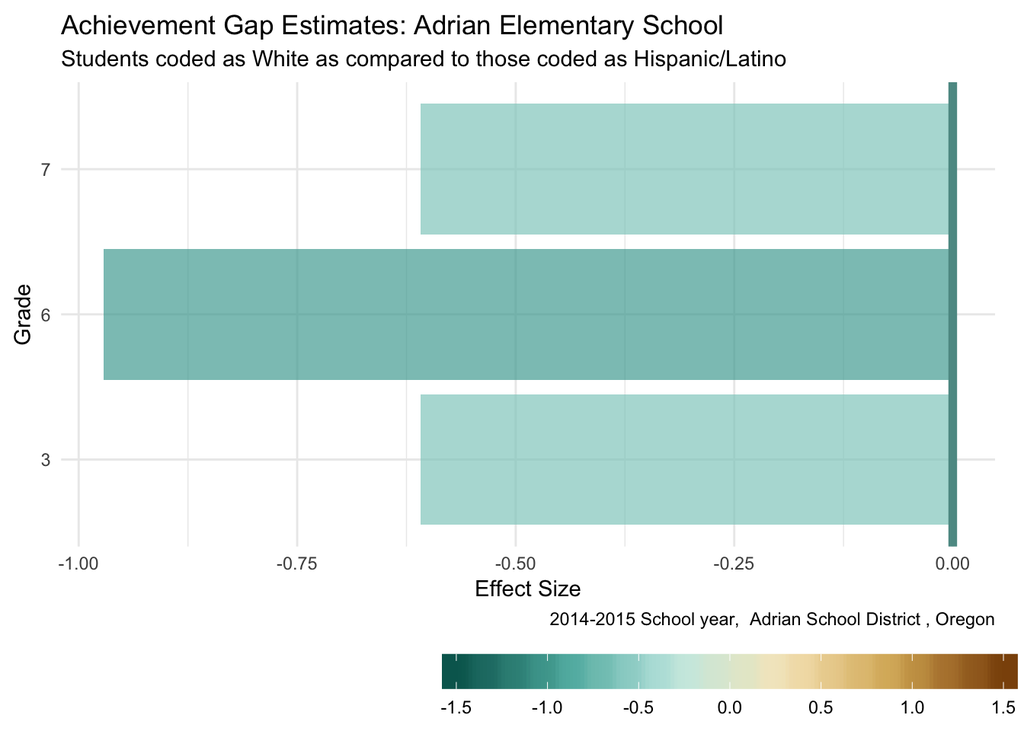

```r
plots <- test1 %>%
  mutate(plots = pmap(list(school, academic_year, data),
                      function(school, academic_year, data) {
                        ggplot(data, aes(factor(grade_level), effect_size)) +
                          geom_col(aes(fill = effect_size), alpha = .7)+
                          geom_hline(yintercept = 0, color = "#5d9993", size = 2) +
                          coord_flip() +
                          scale_fill_distiller(palette = "BrBG", limits = c(-1.5, 1.5)) +
                          theme_minimal() +
                          theme(legend.position = c(.71,-.3),
                                legend.direction = "horizontal",
                                legend.key.width = unit(2, "cm"),
                                plot.margin = margin(b = 1.75, r = 0.5, l = .25, t = .25, unit = "cm")) +
                          labs(x = "Grade",
                               y = "Effect Size",
                               fill = "",
                               title = paste("Achievement Gap Estimates:",school),
                               subtitle = "Students coded as White as compared to those coded as Hispanic/Latino",
                               caption = paste(academic_year, "School year, ",district,", Oregon"))
                    }))
plots$plots[[1]]
```

```r
files <- str_replace_all(tolower(plots$school), " ", "-")
paths <- here::here("plots", glue("{files}.png"))
paths
```

```
##   [1] "/Users/Andre/Documents/plots/adrian-elementary-school.png"
##   [2] "/Users/Andre/Documents/plots/amity-elementary-school.png"
##   [3] "/Users/Andre/Documents/plots/amity-middle-school.png"
##   [4] "/Users/Andre/Documents/plots/walker-elementary-school.png"
##   [5] "/Users/Andre/Documents/plots/helman-elementary-school.png"
##   [6] "/Users/Andre/Documents/plots/ashland-middle-school.png"
##   [7] "/Users/Andre/Documents/plots/ashland-high-school.png"
##   [8] "/Users/Andre/Documents/plots/lewis-&-clark-elementary-school.png"
##   [9] "/Users/Andre/Documents/plots/astoria-middle-school.png"
##  [10] "/Users/Andre/Documents/plots/astoria-senior-high-school.png"
##  [11] "/Users/Andre/Documents/plots/athena-elementary-school.png"
##  [12] "/Users/Andre/Documents/plots/brooklyn-primary-school.png"
##  [13] "/Users/Andre/Documents/plots/south-baker-intermediate-school.png"
##  [14] "/Users/Andre/Documents/plots/baker-web-academy.png"
##  [15] "/Users/Andre/Documents/plots/baker-middle-school.png"
```

[output cut: 85 more lines]

```r
walk2(paths, plots$plots, ggsave,
      width = 9.5,
      height = 6.5,
      dpi = 500)
```